# Number lines and overlaps

16 September 2020

*`interval` objects (`lubridate` package) are the inspiration for `number_line` objects. `number_line` objects are similar but support any `numeric` based object class.*

#Overview

For a given `number_line` object e.g. `8 <- 1`, its main components are;

- `left_point()` - left side of the `number_line` `i.e.` `8`
- `right_point()` - right side of the `number_line` `i.e.` `1`
- `start_point()` - lower end of the range `i.e.` `1`
- `end_point()` - upper end of the range `i.e.` `8`
- `direction` - `"decreasing"` `(<-)`, `"increasing"` `(->)` or no direction `(==)`
- `number_line_width()` - difference between the left and right points `i.e.` `-7`

In `"increasing"` `number_line` objects, the `start_point()` is on the `left_point()`. While in `"decreasing"` `number_line` objects, the `start_point()` is on the `right_point()`.

```r
library(diyar)

nl_a <- number_line(l=c(3,5), r = c(4,1))

# `number_line` objects
nl_a
```

```
#> [1] "3 -> 4" "5 <- 1"
```

```r
# lower end of the range
start_point(nl_a)
```

```
#> [1] 3 1
```

```r
# left part of the range
left_point(nl_a)
```

```
#> [1] 3 5
```

**Figure 1: `number_line` objects**

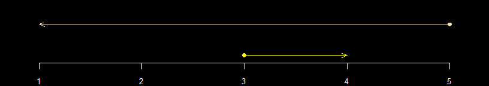

You can reverse the direction of a `number_line` object with `reverse_number_line()`.

```r
# Only reverse decreasing `number_line` objects
nl_b <- reverse_number_line(nl_a, direction = "decreasing"); nl_b
```

```
#> [1] "3 -> 4" "1 -> 5"
```

**Figure 2: Direction of `number_line` objects**

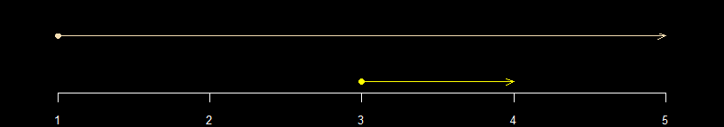

## Manipulating `number_line` objects

`diyar` has convenience functions to reverse, shrink, expand `number_line` objects, or shift them on the number line.

```r
nl_c <- number_line(as.Date("04/04/2019", "%d/%M/%Y"),
                    as.Date("07/04/2019", "%d/%M/%Y"))

nl_c
```

```
#> [1] "2019-09-04 -> 2019-09-07"
```

```r
# expand the `number_line` object by 2 days from both ends
nl_d <- expand_number_line(nl_c, 2); nl_d
```

```
#> [1] "2019-09-02 -> 2019-09-09"
```

```r
# expand the `number_line` object by 2 days from the lower end
nl_e <- expand_number_line(nl_c, 2, "start"); nl_e
```

```
#> [1] "2019-09-02 -> 2019-09-07"
```

```r
# shrink the `number_line` object by 2 days from the upper end
nl_f <- expand_number_line(nl_c, -2, "end"); nl_f
```

```
#> [1] "2019-09-04 -> 2019-09-05"
```

```r
# shrink the `number_line` object by 2 days from both ends
nl_g <- expand_number_line(nl_c, -2); nl_g
```

```
#> [1] "2019-09-06 <- 2019-09-05"
```

```r
# reverse the direction of the `number_line`
nl_h <- reverse_number_line(nl_c); nl_h
```

```
#> [1] "2019-09-07 <- 2019-09-04"
```

```r
# shift the `number_line` object towards the left of the number line by 2 days
nl_i <- shift_number_line(nl_c, -2); nl_g
```

```
#> [1] "2019-09-06 <- 2019-09-05"
```

```r
# shift the `number_line` object towards the right of the number line by 2 days
nl_j <- shift_number_line(nl_c, 2); nl_i
```

```
#> [1] "2019-09-02 -> 2019-09-05"
```

**Figure 3: Manipulated `number_line` objects**

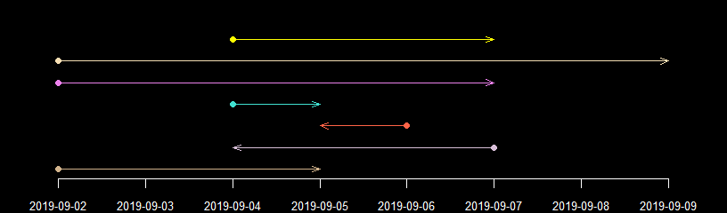

`invert_number_line()` changes each point on the `number_line` from a positive to a negative value and vice versa. See below.

```r
inv <- number_line(c(3,-3,3,-3), c(-6,6,6,-6)); inv
```

```
#> [1] "3 <- -6"  "-3 -> 6"  "3 -> 6"   "-3 <- -6"
```

```r
inv
```

```
#> [1] "3 <- -6"  "-3 -> 6"  "3 -> 6"   "-3 <- -6"
```

```r
invert_number_line(inv)
```

```
#> [1] "-3 -> 6"  "3 <- -6"  "-3 <- -6" "3 -> 6"
```

```r
invert_number_line(inv, "left")
```

```
#> [1] "-3 <- -6" "3 -> 6"   "-3 -> 6"  "3 <- -6"
```

```r
invert_number_line(inv, "start")
```

```
#> [1] "3 -> 6"  "3 -> 6"  "-3 -> 6" "-3 -> 6"
```

```r
invert_number_line(inv, "right")
```

```
#> [1] "3 -> 6"   "-3 <- -6" "3 <- -6"  "-3 -> 6"
```

```r
invert_number_line(inv, "end")
```

```
#> [1] "-3 <- -6" "-3 <- -6" "3 <- -6"  "3 <- -6"
```

You can also convert `number_line` objects to a sequence of `numeric` based values.

```r
nls <- c(nl_c, nl_d, nl_e, nl_f, nl_g, nl_h, nl_i, nl_j)

nls
```

```
#> [1] "2019-09-04 -> 2019-09-07" "2019-09-02 -> 2019-09-09"
#> [3] "2019-09-02 -> 2019-09-07" "2019-09-04 -> 2019-09-05"
#> [5] "2019-09-06 <- 2019-09-05" "2019-09-07 <- 2019-09-04"
#> [7] "2019-09-02 -> 2019-09-05" "2019-09-06 -> 2019-09-09"
```

```r
number_line_sequence(nls, by=2)
```

```
#> [[1]]
#> [1] "2019-09-04" "2019-09-06"
#>
#> [[2]]
#> [1] "2019-09-02" "2019-09-04" "2019-09-06" "2019-09-08"
#>
#> [[3]]
#> [1] "2019-09-02" "2019-09-04" "2019-09-06"
#>
#> [[4]]
#> [1] "2019-09-04"
#>
#> [[5]]
#> [1] "2019-09-06"
#>
#> [[6]]
#> [1] "2019-09-07" "2019-09-05"
#>
#> [[7]]
#> [1] "2019-09-02" "2019-09-04"
#>
#> [[8]]
#> [1] "2019-09-06" "2019-09-08"
```

```r
number_line_sequence(nls, length.out = 3)
```

```
#> [[1]]
#> [1] "2019-09-04" "2019-09-05" "2019-09-07"
#>
#> [[2]]
#> [1] "2019-09-02" "2019-09-05" "2019-09-09"
#>
#> [[3]]
#> [1] "2019-09-02" "2019-09-04" "2019-09-07"
#>
#> [[4]]
#> [1] "2019-09-04" "2019-09-04" "2019-09-05"
#>
#> [[5]]
#> [1] "2019-09-06" "2019-09-05" "2019-09-05"
#>
#> [[6]]
#> [1] "2019-09-07" "2019-09-05" "2019-09-04"
#>
#> [[7]]
#> [1] "2019-09-02" "2019-09-03" "2019-09-05"
#>
#> [[8]]
#> [1] "2019-09-06" "2019-09-07" "2019-09-09"
```

## Overlaps

`number_line` objects can overlap with each other. They do so in seven ways - `"exact"`, `"reverse"`, `"inbetween"`, `"across"`, `"chain"`, `"aligns_start"` and `"aligns_end"`. Each pair of `number_line` objects can only overlap by one of these methods. For example, a `number_line` object with aligned start and end points will be considered an `"exact"` overlap, not `"aligns_start"` and `"aligns_end"`.

*The 7 `overlap_methods` are mutually exclusive.*

**Figure 4a: Example of `exact` overlaps**

```r
exact <- c(number_line(1,2), number_line(1,2),
           number_line(2.5,2.5), number_line(2.5,2.5),
           # negative test - left_point() and left_point()
           # for both must be identical to be an exact match
           number_line(3,4), number_line(4,3))

# positive logical test
exact(exact[c(1,3,5)], exact[c(2,4,6)])
```

```
#> [1]  TRUE  TRUE FALSE
```

```r
# negative logical test
across(exact[c(1,3,5)], exact[c(2,4,6)])
```

```
#> [1] FALSE FALSE FALSE
```

```r
# check overlap methods as defined in `diyar`
overlap_method(exact[c(1,3,5)], exact[c(2,4,6)])
```

```
#> [1] "exact"   "exact"   "reverse"
```

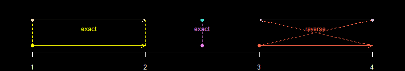

**Figure 4b: Example of `reverse` overlaps**

```r
reverse <- c(number_line(8,6), number_line(6,8),
           number_line(3,4), number_line(4,3),
           # negative test - left_point() and right_point()
           # for both must be swapped to be a reverse match
           number_line(1,2), number_line(1,2))

# positive logical test
reverse(reverse[c(1,3,5)], reverse[c(2,4,6)])
```

```
#> [1]  TRUE  TRUE FALSE
```

```r
# negative logical test
across(reverse[c(1,3,5)], reverse[c(2,4,6)])
```

```
#> [1] FALSE FALSE FALSE
```

```r
# check overlap methods as defined in `diyar`
overlap_method(reverse[c(1,3,5)], reverse[c(2,4,6)])
```

```
#> [1] "reverse" "reverse" "exact"
```

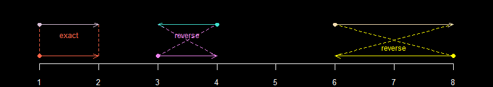

**Figure 4c: Example of `inbetween` overlaps**

```r
inbetween <- c(number_line(5, 8), number_line(6, 7),
               number_line(11, 10), number_line(9, 12),
               number_line(13, 15), as.number_line(14))

# positive logical test
inbetween(inbetween[c(1,3,5)], inbetween[c(2,4,6)])
```

```
#> [1] TRUE TRUE TRUE
```

```r
# negative logical test
across(inbetween[c(1,3,5)], inbetween[c(2,4,6)])
```

```
#> [1] FALSE FALSE FALSE
```

```r
# check overlap methods as defined in `diyar`
overlap_method(inbetween[c(1,3,5)], inbetween[c(2,4,6)])
```

```
#> [1] "inbetween" "inbetween" "inbetween"
```

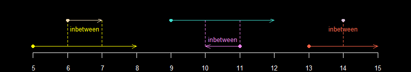

**Figure 4d: Example of `across` overlaps**

```r
across <- c(number_line(16, 19), number_line(18, 21),
            number_line(22, 25), number_line(23, 26),
            number_line(27, 30), number_line(31, 29))

# positive logical test
across(across[c(1,3,5)], across[c(2,4,6)])
```

```
#> [1] TRUE TRUE TRUE
```

```r
# negative logical test
inbetween(across[c(1,3,5)], across[c(2,4,5)])
```

```
#> [1] FALSE FALSE FALSE
```

```r
# check overlap methods as defined in `diyar`
overlap_method(across[c(1,3,5)], across[c(2,4,6)])
```

```
#> [1] "across" "across" "across"
```

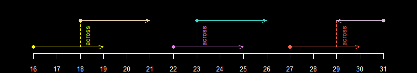

**Figure 4e: Example of `chain` overlaps**

```r
chain <- c(number_line(32, 34), number_line(34, 36),
            number_line(39, 37), number_line(41, 39),
           # negative test - end_point() of one must lead to the start_point()
           # to be considered a chain overlap
           number_line(42, 44), number_line(47, 44))

# positive logical test
chain(chain[c(1,3,5)], chain[c(2,4,6)])
```

```
#> [1]  TRUE  TRUE FALSE
```

```r
# negative logical test
across(chain[c(1,3,5)], chain[c(2,4,6)])
```

```
#> [1] FALSE FALSE FALSE
```

```r
# check overlap methods as defined in `diyar`
overlap_method(chain[c(1,3,5)], chain[c(2,4,6)])
```

```
#> [1] "chain"      "chain"      "aligns_end"
```

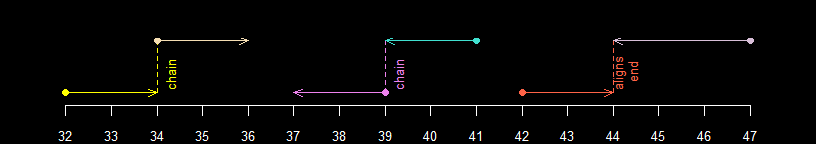

**Figure 4f: Example of `aligns_start` overlaps**

```r
aligns_start <- c(number_line(45, 46), number_line(45, 47),
            number_line(48, 49.5), number_line(48, 48),
            number_line(51, 50), number_line(51, 52))

# positive logical test
aligns_start(aligns_start[c(1,3,5)], aligns_start[c(2,4,6)])
```

```
#> [1] TRUE TRUE TRUE
```

```r
# negative logical test
across(aligns_start[c(1,3,5)], aligns_start[c(2,4,6)])
```

```
#> [1] FALSE FALSE FALSE
```

```r
# check overlap methods as defined in `diyar`
overlap_method(aligns_start[c(1,3,5)], aligns_start[c(2,4,6)])
```

```
#> [1] "aligns_start" "aligns_start" "aligns_start"
```

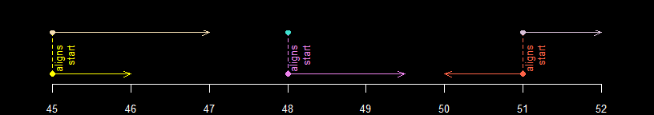

**Figure 4g: Example of `aligns_end` overlaps**

```r
aligns_end <- c(number_line(54, 55), number_line(53, 55),
            number_line(56, 57.5), number_line(57.5, 57.5),
            number_line(58, 59), number_line(60, 59))

# positive logical test
aligns_end(aligns_end[c(1,3,5)], aligns_end[c(2,4,6)])
```

```
#> [1] TRUE TRUE TRUE
```

```r
# negative logical test
across(aligns_end[c(1,3,5)], aligns_end[c(2,4,6)])
```

```
#> [1] FALSE FALSE FALSE
```

```r
# check overlap methods as defined in `diyar`
overlap_method(aligns_end[c(1,3,5)], aligns_end[c(2,4,6)])
```

```
#> [1] "aligns_end" "aligns_end" "aligns_end"
```

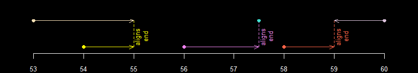

## Set operations

Set operations can be performed on `number_line` objects.

```r
a <- number_line(1,10); b <- number_line(5, 15)
c <- union_number_lines(a, b)
a; b; c
```

```
#> [1] "1 -> 10"
#> [1] "5 -> 15"
#> [1] "1 -> 15"
```

**Figure 5a: Union**

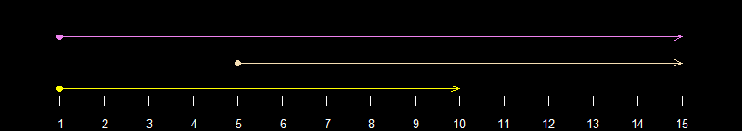

```r
c <- intersect_number_lines(a, b)
a; b; c
```

```
#> [1] "1 -> 10"
#> [1] "5 -> 15"
#> [1] "5 -> 10"
```

**Figure 5b: Intersection**

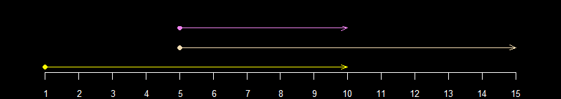

```r
c <- subtract_number_lines(a, b)
a; b; c
```

```
#> [1] "1 -> 10"
#> [1] "5 -> 15"
#> $n1
#> [1] "1 -> 5"
#>
#> $n2
#> [1] "10 -> 15"
```

**Figure 5c: Subtraction**

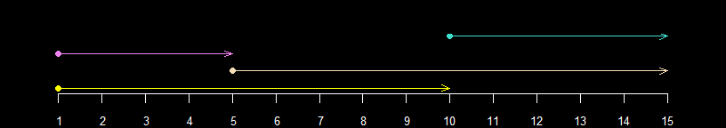

## Compressing `number_line` objects

You can compress a pair of overlapping `number_line` objects into one by using `compress_number_line()`. You can also choose to compress only those that overlap in a certain way.

When overlapping `number_line` objects have different directions, the resulting compressed `number_line` object inherits the direction of the widest among them. If they have the same width, the compressed `number_line` object takes an `"increasing"` direction.

**Figure 6. Pairs of `number_line` objects overlapping by `"inbetween"` and `"exact"` methods compressed into one**

```r
cnl_a <- c(inbetween, exact); cnl_a
```

```
#>  [1] "5 -> 8"     "6 -> 7"     "11 <- 10"   "9 -> 12"    "13 -> 15"
#>  [6] "14 == 14"   "1 -> 2"     "1 -> 2"     "2.5 == 2.5" "2.5 == 2.5"
#> [11] "3 -> 4"     "4 <- 3"
```

```r
cmp_a <- compress_number_line(cnl_a, deduplicate = T); cmp_a
```

```
#> [1] "5 -> 8"     "9 -> 12"    "13 -> 15"   "1 -> 2"     "2.5 == 2.5"
#> [6] "3 -> 4"
```

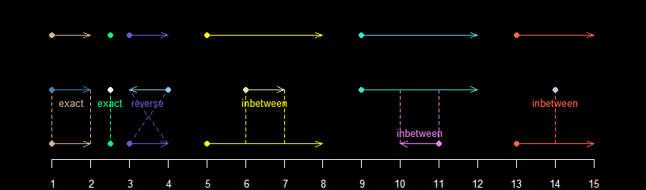

**Figure 7. Pairs of `number_line` objects overlapping by `"across"` and `"chain"` methods compressed into one**

```r
cnl_b <- c(across, chain); cnl_b
```

```
#>  [1] "16 -> 19" "18 -> 21" "22 -> 25" "23 -> 26" "27 -> 30" "31 <- 29"
#>  [7] "32 -> 34" "34 -> 36" "39 <- 37" "41 <- 39" "42 -> 44" "47 <- 44"
```

```r
cmp_b <- compress_number_line(cnl_b, deduplicate = T); cmp_b
```

```
#> [1] "16 -> 21" "22 -> 26" "27 -> 31" "32 -> 36" "41 <- 37" "47 <- 42"
```

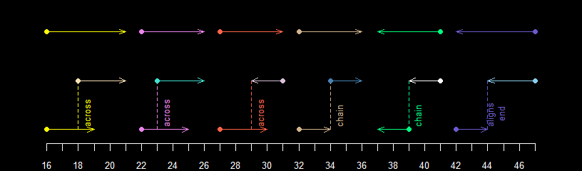

Compress `number_line` objects that overlap in a particular way by using the `methods` argument.

**Figure 8. Pairs of `number_line` objects overlapping by `"aligns_start"` and `"exact"` methods compressed into one**

```r
cnl_c <- c(aligns_start, aligns_end); cnl_c
```

```
#>  [1] "45 -> 46"     "45 -> 47"     "48 -> 49.5"   "48 == 48"     "51 <- 50"
#>  [6] "51 -> 52"     "54 -> 55"     "53 -> 55"     "56 -> 57.5"   "57.5 == 57.5"
#> [11] "58 -> 59"     "60 <- 59"
```

```r
cmp_c <- compress_number_line(cnl_c, deduplicate = T, methods ="aligns_start|exact"); cmp_c
```

```
#> [1] "45 -> 47"     "48 -> 49.5"   "50 -> 52"     "54 -> 55"     "53 -> 55"
#> [6] "56 -> 57.5"   "57.5 == 57.5" "58 -> 59"     "60 <- 59"
```

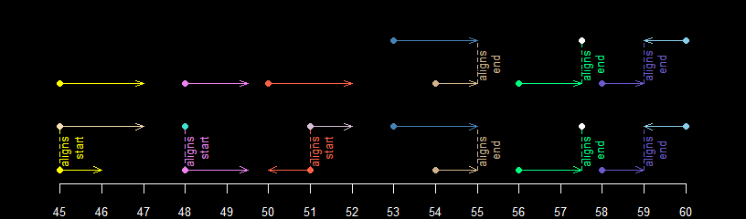

## Collapsing `number_line` objects

The resulting compressed `number_line` object can yet again overlap with others. Especially when using specific `methods`. This doesn’t happen by default but you can do so by changing `collapse` to `TRUE`.

It’s worth mentioning that this process starts from the first `number_line` object in the set. Therefore, changing their position in the set can lead to different results.

**Figure 9a: Compressing pairs of `number_line` objects by `"across"`, `"chain"`, `"inbetween"` and `"aligns_end"` methods**

```r
nl_z <- number_line(l= c(1,2,4,5,6), r = c(3,4,8,8,7))
nl_z
```

```
#> [1] "1 -> 3" "2 -> 4" "4 -> 8" "5 -> 8" "6 -> 7"
```

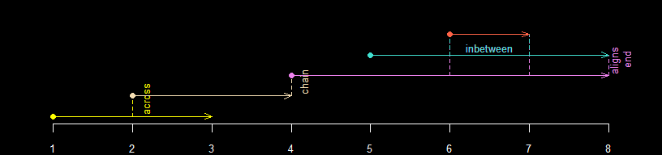

```r
cmp_z <- compress_number_line(nl_z, methods = "across|chain")

cmp_z
```

```
#> [1] "1 -> 4" "4 -> 8" "5 -> 8" "6 -> 7"
```

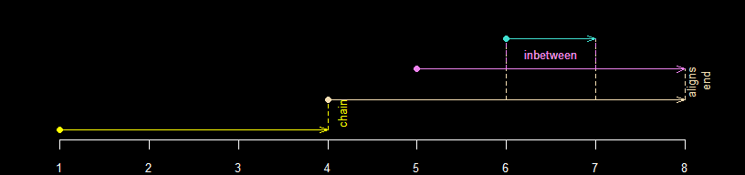

As mentioned, if each `number_line` object’s position in the set changes, the result could also change. See below.

```r
nl_zb <- nl_z[c(2:5,1)]; nl_zb
```

```
#> [1] "2 -> 4" "4 -> 8" "5 -> 8" "6 -> 7" "1 -> 3"
```

```r
cmp_zb <- compress_number_line(nl_zb, methods = "across|chain"); cmp_zb
```

```
#> [1] "1 -> 8" "5 -> 8" "6 -> 7"
```

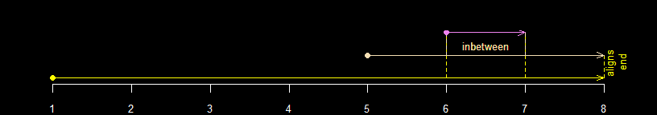

Changing `collapse` to `TRUE` will collapse (rather than compress) the initial set (`nl_z`). This gives the same result as compressing the rearranged version (`nl_zb`).

```r
cmp_zba <- compress_number_line(nl_z, methods = "across|chain", collapse = T); cmp_zba
```

```
#> [1] "1 -> 8" "5 -> 8" "6 -> 7"
```

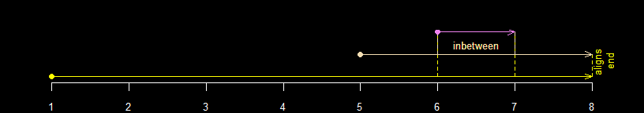

`episodes()` is a more advanced implementations of `compress_number_line()`. It can compress (`"fixed_episodes"`) and collapse (`"rolling_episodes"`) overlapping `number_line` objects. It has additional useful features such as controlling the order in which pairs are compressed i.e. chronological order (`from_last`) or a user-defined order (`custom_sort`). See episode grouping for more information.